# Practical 1: Creating Interactive Visualisations Using Tableau

| Information | Details |
| --- | --- |
| Module ID | `CS5044` |
| Author | 250025167 |

## I. Data Exploration

Before conducting the data familiarisation, this section summarises the key information provided in the documentation linked to the practical PDF (CPJ Doc: https://cpj.org/data/methodology/).

### A) Analysis of the documentation

#### 1 - Source of the database

The data is collected from a wide variety of primary and secondary sources to ensure global coverage. CPJ researchers collect information from:

- Local and international media reports.
- Human rights organizations and journalists’ unions.
- Direct testimony from local correspondents, family members, or colleagues of the victims.

#### 2 - Timeline

The database tracks incidents spanning from 1992 to the present (as per documentation).

#### 3 - Data collection methodology

The collection process is manual:

- Every case is independently verified by CPJ researchers.
- Information is cross-checked across multiple sources to ensure accuracy.
- The CPJ only classifies a death as *confirmed* if they can affirm with reasonable certainty that the journalist was killed because of their work.

#### 4 - Key Variables

To understand the dataset, several key definitions and classifications are used:

- *Definition of Journalist*: Includes anyone who regularly covers news or comments on public affairs through any medium to share fact-based information.
- *Classification*: Deaths are categorized as *Confirmed* (motive confirmed) or *Unconfirmed* (motive is not yet proven, though the journalist was killed).
- *Media Workers*: Note that media workers (e.g., drivers, translators) are usually tracked separately from the main journalist category in separate datasets.

#### 5 - Constraints of the database

While comprehensive, the database has specific limitations:

- *Manual Updates*: Since the database is updated manually when new information surfaces, there can be a slight lag in real-time reporting.
- *Verification Barriers*: If information is insufficient or impossible to verify, a case may remain *unconfirmed* indefinitely.
- *Data Labeling*: Because data comes from diverse global sources, inconsistencies or errors in labeling can occur.
- *Intentional Gaps*: Specific data points may be listed as *unknown* (such as place of death) intentionally when information cannot be verified, rather than being a mistake.

### B) Basic Analysis

```python
# Import pandas and numpy libraries
import pandas as pd
import numpy as np
```

```python
# Load the CSV file into a dataframe
df = pd.read_csv("raw data/Practical1_Journalists_Killed_Imprisoned_1992_2020.csv")
pd.set_option("display.max_colwidth", None)

# Standardize missing values by replacing common placeholders with NaN
missing_like = ["", " ", "NA", "N/A", "null", "NULL", "None", "NONE", "Unknown", "unknown"]
df = df.replace(missing_like, np.nan)

# Remove leading/trailing spaces and normalize multiple spaces in text columns
df = df.apply(lambda x: x.str.replace(r"\s+", " ", regex=True).str.strip() if x.dtype == "object" else x)
```

```python
# Display basic information about the dataset
print("Shape:", df.shape)

print("------------------------------------------------")
print("Random Sample of the Dataset:")
print("------------------------------------------------")
display(df.sample(5, random_state=100))

print("------------------------------------------------")
print("Data Types by Column:")
print("------------------------------------------------")
display(df.dtypes.sort_values())

print("------------------------------------------------")
print("Descriptive Statistics and Dataset Summary:")
print("------------------------------------------------")
display(df.describe(include="all").T)
```

```
Shape: (6763, 31)
------------------------------------------------
Random Sample of the Dataset:
------------------------------------------------
```

|  | year | fullName | primaryNationality | gender | photoUrl | type | typeOfDeath | status | employedAs | organizations | ... | motiveConfirmed | impunityMurder | tortured | captive | threatened | charges | lengthOfSentence | impCountry | sentence | locationImprisoned |
| --- | --- | --- | --- | --- | --- | --- | --- | --- | --- | --- | --- | --- | --- | --- | --- | --- | --- | --- | --- | --- | --- |
| 4414 | 2010 | Aung Kyaw San | Myanmar | Male | NaN | Journalist | NaN | Imprisoned | Staff | Myanmar Tribune | ... | NaN | NaN | NaN | NaN | NaN | Retaliatory | 1 year to <5 years | NaN | 2 years | NaN |
| 4391 | 2010 | Abdolreza Tajik | Iran | Male | NaN | Journalist | NaN | Imprisoned | Freelance | Freelance | ... | NaN | NaN | NaN | NaN | NaN | Anti-State | Not Sentenced | NaN | Not Sentenced | NaN |
| 5391 | 2014 | Liu Xianbin | China | Male | https://cpj-photos.s3.amazonaws.com/Liu%20Xianbin_China%20Political%20Prisoner%20Concern%20case%2000002-2017-12-18-1513625140573.jpg | Journalist | NaN | Imprisoned | Freelance | Freelance | ... | NaN | NaN | NaN | NaN | NaN | Anti-state | 10+ years | NaN | 10 years | Chuanzhong, Sichuan |
| 712 | 2005 | Gautam Das | Bangladesh | Male | NaN | Journalist | Murder | Killed | Staff | Samakal | ... | Confirmed | Partial Impunity | No | No | No | NaN | NaN | NaN | NaN | NaN |
| 349 | 1998 | Isabel Chumpitaz Panta | NaN | NaN | NaN | Journalist | NaN | Killed | Staff | Radio Satélite | ... | Unconfirmed | NaN | NaN | NaN | NaN | NaN | NaN | NaN | NaN | NaN |

5 rows × 31 columns

```
------------------------------------------------
Data Types by Column:
------------------------------------------------
```

```
year                    int64
impCountry            float64
lengthOfSentence       object
charges                object
threatened             object
captive                object
tortured               object
impunityMurder         object
motiveConfirmed        object
sourcesOfFire          object
localOrForeign         object
province               object
locality               object
state                  object
sentence               object
region                 object
country                object
mediums                object
coverage               object
jobs                   object
organizations          object
employedAs             object
status                 object
typeOfDeath            object
type                   object
photoUrl               object
gender                 object
primaryNationality     object
fullName               object
location               object
locationImprisoned     object
dtype: object
```

```
------------------------------------------------
Descriptive Statistics and Dataset Summary:
------------------------------------------------
```

|  | count | unique | top | freq | mean | std | min | 25% | 50% | 75% | max |
| --- | --- | --- | --- | --- | --- | --- | --- | --- | --- | --- | --- |
| year | 6763.0 | NaN | NaN | NaN | 2007.268668 | 8.194894 | 1992.0 | 2000.0 | 2009.0 | 2014.0 | 2020.0 |
| fullName | 6763 | 3588 | Ghebrehiwet Keleta | 20 | NaN | NaN | NaN | NaN | NaN | NaN | NaN |
| primaryNationality | 6121 | 147 | China | 946 | NaN | NaN | NaN | NaN | NaN | NaN | NaN |
| gender | 6203 | 2 | Male | 5707 | NaN | NaN | NaN | NaN | NaN | NaN | NaN |
| photoUrl | 947 | 536 | https://cpj-photos.s3.amazonaws.com/Amanuel%20Asrat_1-2018-01-02-1514916488565.jpg | 19 | NaN | NaN | NaN | NaN | NaN | NaN | NaN |
| type | 6763 | 1 | Journalist | 6763 | NaN | NaN | NaN | NaN | NaN | NaN | NaN |
| typeOfDeath | 1356 | 3 | Murder | 870 | NaN | NaN | NaN | NaN | NaN | NaN | NaN |
| status | 6763 | 2 | Imprisoned | 4854 | NaN | NaN | NaN | NaN | NaN | NaN | NaN |
| employedAs | 5995 | 3 | Staff | 4386 | NaN | NaN | NaN | NaN | NaN | NaN | NaN |
| organizations | 6721 | 2138 | Freelance | 1241 | NaN | NaN | NaN | NaN | NaN | NaN | NaN |
| jobs | 6096 | 184 | Editor | 932 | NaN | NaN | NaN | NaN | NaN | NaN | NaN |
| coverage | 5255 | 185 | Politics | 1732 | NaN | NaN | NaN | NaN | NaN | NaN | NaN |
| mediums | 6138 | 40 | Print | 2923 | NaN | NaN | NaN | NaN | NaN | NaN | NaN |
| country | 6763 | 131 | China | 957 | NaN | NaN | NaN | NaN | NaN | NaN | NaN |
| location | 2709 | 1134 | Istanbul | 160 | NaN | NaN | NaN | NaN | NaN | NaN | NaN |
| region | 89 | 22 | Xinjiang | 55 | NaN | NaN | NaN | NaN | NaN | NaN | NaN |
| state | 79 | 58 | Western Bahr al Ghazal state | 5 | NaN | NaN | NaN | NaN | NaN | NaN | NaN |
| locality | 2650 | 1119 | Istanbul | 159 | NaN | NaN | NaN | NaN | NaN | NaN | NaN |
| province | 231 | 78 | Sichuan | 35 | NaN | NaN | NaN | NaN | NaN | NaN | NaN |
| localOrForeign | 6290 | 2 | Local | 6001 | NaN | NaN | NaN | NaN | NaN | NaN | NaN |
| sourcesOfFire | 1163 | 32 | Political Group | 441 | NaN | NaN | NaN | NaN | NaN | NaN | NaN |
| motiveConfirmed | 1909 | 2 | Confirmed | 1365 | NaN | NaN | NaN | NaN | NaN | NaN | NaN |
| impunityMurder | 873 | 3 | Complete Impunity | 710 | NaN | NaN | NaN | NaN | NaN | NaN | NaN |
| tortured | 870 | 2 | No | 769 | NaN | NaN | NaN | NaN | NaN | NaN | NaN |
| captive | 870 | 2 | No | 681 | NaN | NaN | NaN | NaN | NaN | NaN | NaN |
| threatened | 870 | 2 | No | 507 | NaN | NaN | NaN | NaN | NaN | NaN | NaN |
| charges | 4676 | 46 | Anti-State | 2212 | NaN | NaN | NaN | NaN | NaN | NaN | NaN |
| lengthOfSentence | 4476 | 15 | 10+ years | 1354 | NaN | NaN | NaN | NaN | NaN | NaN | NaN |
| impCountry | 0.0 | NaN | NaN | NaN | NaN | NaN | NaN | NaN | NaN | NaN | NaN |
| sentence | 4469 | 110 | Not Sentenced | 994 | NaN | NaN | NaN | NaN | NaN | NaN | NaN |
| locationImprisoned | 835 | 101 | Istanbul | 142 | NaN | NaN | NaN | NaN | NaN | NaN | NaN |

```python
# Create a summary table describing key characteristics of each column:
# - number of unique values
# - percentage of unique values
# - proportion of missing values
#
# This overview helps identify:
# - high-cardinality variables
# - potential data quality issues
# - columns that may not be suitable for visualization

u_table = pd.DataFrame({"n_unique": df.nunique(dropna=True)})
u_table["ttl_size"] = len(df)
u_table["unique_%"] = (u_table["n_unique"] / len(df) * 100).round(2)
u_table["NaN_%"] = (df.isna().mean() * 100).round(2)

print("------------------------------------------------")
print("Column Summary: Unique Values and Missing Data")
print("------------------------------------------------")
display(u_table.sort_values("n_unique", ascending=False))
```

```
------------------------------------------------
Column Summary: Unique Values and Missing Data
------------------------------------------------
```

|  | n_unique | ttl_size | unique_% | NaN_% |
| --- | --- | --- | --- | --- |
| fullName | 3588 | 6763 | 53.05 | 0.00 |
| organizations | 2138 | 6763 | 31.61 | 0.62 |
| location | 1134 | 6763 | 16.77 | 59.94 |
| locality | 1119 | 6763 | 16.55 | 60.82 |
| photoUrl | 536 | 6763 | 7.93 | 86.00 |
| coverage | 185 | 6763 | 2.74 | 22.30 |
| jobs | 184 | 6763 | 2.72 | 9.86 |
| primaryNationality | 147 | 6763 | 2.17 | 9.49 |
| country | 131 | 6763 | 1.94 | 0.00 |
| sentence | 110 | 6763 | 1.63 | 33.92 |
| locationImprisoned | 101 | 6763 | 1.49 | 87.65 |
| province | 78 | 6763 | 1.15 | 96.58 |
| state | 58 | 6763 | 0.86 | 98.83 |
| charges | 46 | 6763 | 0.68 | 30.86 |
| mediums | 40 | 6763 | 0.59 | 9.24 |
| sourcesOfFire | 32 | 6763 | 0.47 | 82.80 |
| year | 29 | 6763 | 0.43 | 0.00 |
| region | 22 | 6763 | 0.33 | 98.68 |
| lengthOfSentence | 15 | 6763 | 0.22 | 33.82 |
| employedAs | 3 | 6763 | 0.04 | 11.36 |
| typeOfDeath | 3 | 6763 | 0.04 | 79.95 |
| impunityMurder | 3 | 6763 | 0.04 | 87.09 |
| status | 2 | 6763 | 0.03 | 0.00 |
| localOrForeign | 2 | 6763 | 0.03 | 6.99 |
| motiveConfirmed | 2 | 6763 | 0.03 | 71.77 |
| tortured | 2 | 6763 | 0.03 | 87.14 |
| captive | 2 | 6763 | 0.03 | 87.14 |
| threatened | 2 | 6763 | 0.03 | 87.14 |
| gender | 2 | 6763 | 0.03 | 8.28 |
| type | 1 | 6763 | 0.01 | 0.00 |
| impCountry | 0 | 6763 | 0.00 | 100.00 |

```python
# Since most columns in the dataframe are of type "object",
# we examine the distribution of values for each categorical column
cat_cols = df.select_dtypes(include="object").columns

# Display the most frequent values in each categorical column
for col in cat_cols:
    counts = df[col].value_counts()
    duplicates = counts[counts > 1]

    if not duplicates.empty:
        print("------------------------------------------------")
        print("Column:", col)
        print("------------------------------------------------")
        print(duplicates.head(10))
```

```
------------------------------------------------
Column: fullName
------------------------------------------------
fullName
Ghebrehiwet Keleta             20
Tesfay ‘Gomora’ Ghebreab       19
Yusuf Ruzimuradov              19
Medhanie Haile                 19
Mattewos Habteab               19
Yusuf Mohamed Ali              19
Temesgen Ghebreyesus           19
Idris Said (Abba Arre)         19
Said Abdelkader                19
Sahle Tsegazeab (Wedi Itay)    19
Name: count, dtype: int64
------------------------------------------------
Column: primaryNationality
------------------------------------------------
primaryNationality
China       946
Turkey      806
Eritrea     462
Iran        318
Syria       275
Myanmar     246
Cuba        199
Vietnam     199
Iraq        191
Ethiopia    184
Name: count, dtype: int64
------------------------------------------------
Column: gender
------------------------------------------------
gender
Male      5707
Female     496
Name: count, dtype: int64
------------------------------------------------
Column: photoUrl
------------------------------------------------
```

[output cut: 290 more lines]

```
------------------------------------------------
Column: locationImprisoned
------------------------------------------------
locationImprisoned
Istanbul            142
Cairo                58
Jaw                  35
Urumqi, Xinjiang     27
Baku                 27
Kocaeli              23
Dammam               21
Eiraeiro Prison      19
Carceli Prison       18
Damascus             18
Name: count, dtype: int64
```

```python
# Temporarily normalize text to detect inconsistent labels
# (e.g. differences in capitalization or spacing)
def normalize_text(series):
    return (
        series.astype("string")
        .str.strip()
        .str.lower()
        .str.replace(r"\s+", " ", regex=True)
    )

# Identify categorical values that differ only by formatting
# by comparing original values with their normalized version
def find_case_variants(df, col):
    temp = pd.DataFrame({"original": df[col].dropna(), "normalized": normalize_text(df[col].dropna())})
    grouped = (temp.groupby("normalized")["original"].unique().reset_index())

    grouped["n_variants"] = grouped["original"].apply(len)
    variants = grouped[grouped["n_variants"] > 1]
    return variants.sort_values("n_variants", ascending=False)
```

```python
# Detect inconsistent labels in categorical columns (like differences in typo, capitale letter or spacing).
for i, col in enumerate(cat_cols, start=1):
    variants = find_case_variants(df, col)

    if not variants.empty:
        print("------------------------------------------------")
        print(f"Column n°{i}: {col}")
        print("------------------------------------------------")

        display(variants)
```

[output not shown]

|  | normalized | original | n_variants |
| --- | --- | --- | --- |
| 1 | staff | [Staff, staff] | 2 |

```
------------------------------------------------
Column n°9: organizations
------------------------------------------------
```

|  | normalized | original | n_variants |
| --- | --- | --- | --- |
| 540 | dicle news agency (di̇ha) | [Dicle News Agency (DİHA), Dicle news Agency (DİHA)] | 2 |
| 692 | el-shaab el-jadeed | [El-Shaab el-Jadeed, el-Shaab el-Jadeed] | 2 |
| 780 | former journalist | [Former journalist, former journalist] | 2 |
| 791 | freelance | [Freelance, freelance] | 2 |

```
------------------------------------------------
Column n°10: jobs
------------------------------------------------
```

|  | normalized | original | n_variants |
| --- | --- | --- | --- |
| 113 | internet reporter, print reporter | [Internet reporter, Print reporter, Internet Reporter, Print Reporter, Internet reporter, print reporter, Internet Reporter, Print reporter] | 4 |
| 97 | editor, internet reporter, print reporter | [Editor, Internet reporter, Print reporter, Editor, Internet Reporter, Print reporter, Editor, Internet Reporter, Print Reporter] | 3 |
| 12 | broadcast reporter, internet reporter, print reporter | [Broadcast Reporter, Internet Reporter, Print Reporter, Broadcast Reporter, Internet Reporter, Print reporter] | 2 |
| 140 | print reporter | [Print Reporter, Print reporter] | 2 |
| 132 | photographer, print reporter | [Photographer, Print Reporter, Photographer, Print reporter] | 2 |
| 119 | internet reporter, publisher/owner | [Internet Reporter, Publisher/Owner, Internet reporter, Publisher/Owner] | 2 |
| 118 | internet reporter, producer, publisher/owner | [Internet Reporter, Producer, Publisher/Owner, Internet Reporter, Producer, Publisher/owner] | 2 |
| 116 | internet reporter, print reporter, publisher/owner | [Internet Reporter, Print Reporter, Publisher/Owner, Internet Reporter, Print reporter, Publisher/Owner] | 2 |
| 110 | internet reporter | [Internet Reporter, Internet reporter] | 2 |
| 101 | editor, print reporter, publisher/owner | [Editor, Print reporter, Publisher/Owner, Editor, Print Reporter, Publisher/Owner] | 2 |
| 100 | editor, print reporter | [Editor, Print Reporter, Editor, Print reporter] | 2 |
| 0 | broadcast reporter | [Broadcast Reporter, Broadcast reporter] | 2 |
| 96 | editor, internet reporter, photographer, print reporter | [Editor, Internet Reporter, Photographer, Print Reporter, Editor, Internet Reporter, Photographer, Print reporter] | 2 |
| 78 | columnist/commentator, print reporter | [Columnist/Commentator, Print Reporter, Columnist/Commentator, Print reporter] | 2 |
| 76 | columnist/commentator, internet reporter, print reporter | [Columnist/Commentator, Internet Reporter, Print reporter, Columnist/Commentator, Internet Reporter, Print Reporter] | 2 |
| 70 | columnist/commentator, editor | [Columnist/Commentator, Editor, Columnist/commentator, Editor] | 2 |
| 69 | columnist/commentator | [Columnist/Commentator, Columnist/commentator] | 2 |
| 43 | camera operator, documentary filmmaker, internet reporter, producer | [Camera Operator, Documentary filmmaker, Internet Reporter, Producer, Camera Operator, Documentary Filmmaker, Internet Reporter, Producer] | 2 |
| 42 | camera operator | [Camera Operator, Camera operator] | 2 |
| 40 | broadcast reporter,publisher/owner | [Broadcast Reporter,Publisher/Owner, Broadcast reporter,Publisher/Owner] | 2 |
| 14 | broadcast reporter, print reporter | [Broadcast reporter, Print reporter, Broadcast Reporter, Print Reporter] | 2 |
| 153 | publisher/owner | [Publisher/Owner, Publisher/owner] | 2 |

```
------------------------------------------------
Column n°11: coverage
------------------------------------------------
```

|  | normalized | original | n_variants |
| --- | --- | --- | --- |
| 140 | human rights, politics | [Human Rights, Politics, Human rights, Politics, Human rights, politics, Human Rights, politics] | 4 |
| 68 | corruption, human rights | [Corruption, Human Rights, Corruption, Human rights] | 2 |
| 69 | corruption, human rights, politics | [Corruption, Human Rights, Politics, Corruption, Human rights, Politics] | 2 |
| 72 | corruption, politics | [Corruption, Politics, Corruption, politics] | 2 |
| 102 | crime, human rights | [Crime, Human Rights, Crime, Human rights] | 2 |
| 122 | culture, politics | [Culture, Politics, Culture, politics] | 2 |
| 139 | human rights | [Human Rights, Human rights] | 2 |
| 143 | human rights, politics, war | [Human Rights, Politics, War, Human rights, Politics, War] | 2 |
| 144 | human rights, war | [Human rights, War, Human Rights, War] | 2 |
| 166 | sports | [Sports, sports] | 2 |

```
------------------------------------------------
Column n°12: mediums
------------------------------------------------
```

|  | normalized | original | n_variants |
| --- | --- | --- | --- |
| 17 | print | [Print, print] | 2 |

```
------------------------------------------------
Column n°14: location
------------------------------------------------
```

|  | normalized | original | n_variants |
| --- | --- | --- | --- |
| 300 | deir al-zour | [Deir al-Zour, Deir Al-Zour] | 2 |
| 818 | place of death unknown | [place of death unknown, Place of death unknown] | 2 |

```
------------------------------------------------
Column n°17: locality
------------------------------------------------
```

|  | normalized | original | n_variants |
| --- | --- | --- | --- |
| 297 | deir al-zour | [Deir al-Zour, Deir Al-Zour] | 2 |
| 806 | place of death unknown | [place of death unknown, Place of death unknown] | 2 |

```
------------------------------------------------
Column n°26: charges
------------------------------------------------
```

|  | normalized | original | n_variants |
| --- | --- | --- | --- |
| 9 | anti-state, false news | [Anti-State, False News, Anti-State, False news, Anti-State, false news, Anti-state, False News, Anti-state, False news] | 5 |
| 12 | anti-state, retaliatory | [Anti-State, Retaliatory, Anti-state, Retaliatory, Anti-state, retaliatory] | 3 |
| 0 | anti-state | [Anti-State, Anti-state] | 2 |
| 1 | anti-state, censorship violation | [Anti-State, Censorship Violation, Anti-state, Censorship Violation] | 2 |
| 2 | anti-state, defamation | [Anti-State, Defamation, Anti-state, Defamation] | 2 |
| 4 | anti-state, defamation, false news | [Anti-State, Defamation, False News, Anti-state, Defamation, False News] | 2 |
| 6 | anti-state, ethnic or religious insult, retaliatory | [Anti-state, Ethnic or religious insult, Retaliatory, Anti-State, Ethnic or religious insult, Retaliatory] | 2 |
| 10 | anti-state, false news, retaliatory | [Anti-State, False News, Retaliatory, Anti-state, False News, Retaliatory] | 2 |
| 13 | censorship violation | [Censorship Violation, Censorship violation] | 2 |
| 16 | defamation, false news | [Defamation, False news, Defamation, False News] | 2 |
| 18 | ethnic or religious insult | [Ethnic or religious insult, Ethnic or Religious Insult] | 2 |
| 21 | false news | [False news, False News] | 2 |
| 24 | no charge | [No charge, No Charge] | 2 |

```
------------------------------------------------
Column n°27: lengthOfSentence
------------------------------------------------
```

|  | normalized | original | n_variants |
| --- | --- | --- | --- |
| 8 | not sentenced | [Not Sentenced, Not sentenced, not Sentenced] | 3 |
| 0 | 0-5 years | [0-5 years, 0-5 Years] | 2 |
| 2 | 10+ years | [10+ years, 10+ Years] | 2 |
| 4 | 5-10 years | [5-10 years, 5-10 Years] | 2 |

```
------------------------------------------------
Column n°28: sentence
------------------------------------------------
```

|  | normalized | original | n_variants |
| --- | --- | --- | --- |
| 1 | 1 year | [1 year, 1 Year] | 2 |
| 14 | 12 years | [12 years, 12 Years] | 2 |
| 77 | 5 years | [5 years, 5 Years] | 2 |
| 90 | 7 years | [7 years, 7 Years] | 2 |
| 102 | not sentenced | [Not Sentenced, Not sentenced] | 2 |

Now, we also want to examine whether different columns contain overlapping values. The goal is not only to identify similarities between variables, but also to detect possible data quality issues, such as values that may have been entered in the wrong column.

To do so, we compute a similarity matrix between categorical columns using the Jaccard similarity coefficient:

$$Similarity = \frac{|A \cap B|}{|A \cup B|}$$

For each pair of columns, we compare their sets of unique values. A high similarity score means that the two columns share many values. This can reveal:

1. redundancy between columns
2. conceptual overlap
3. or values that may be misplaced

After identifying suspicious column pairs, we can list the shared values and inspect them manually in order to confirm whether they are valid or incorrect. For example, if two semantically different columns share the same values, those shared elements can be extracted and reviewed individually to determine whether they correspond to valid overlap or to a placement error.

```python
# Comparison of element between to of the same colunm, by using Jaccard similarity
# Import seaborn and matplotlibs libraries
import seaborn as sns
import matplotlib.pyplot as plt
from matplotlib.colors import LogNorm

columns = df.select_dtypes(include="object").columns
matrix = pd.DataFrame(index=columns, columns=columns, dtype=float)

# Compute pairwise Jaccard similarity between categorical columns
for col1 in columns:
    # Create a set of unique non-null values for the first column
    set1 = set(df[col1].dropna().astype(str))

    for col2 in columns:
        # Create a set of unique non-null values for the second column
        set2 = set(df[col2].dropna().astype(str))

        # Compute intersection and union of both sets
        intersection = len(set1 & set2)
        union = len(set1 | set2)

        # Calculate Jaccard similarity score
        if union == 0:
            score = 0
        else:
            score = intersection / union

        # Store the similarity score in the matrix
        matrix.loc[col1, col2] = score
```

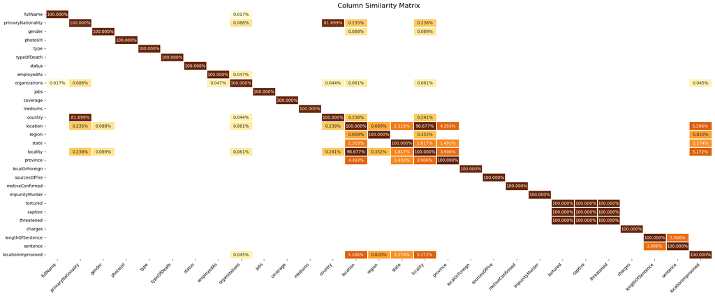

```python
# Visualize the similarity matrix using a heatmap
plt.figure(figsize=(24,10))

# Hide cells with zero similarity to improve readability
mask = (matrix == 0)
sns.heatmap(
    matrix,
    mask=mask,
    cmap="YlOrBr",
    annot=True,
    fmt=".3%",
    vmax=0.1,
    norm=LogNorm(vmin=0.0001, vmax=1),
    linewidths=1,
    cbar=False
)

plt.title("Column Similarity Matrix", fontsize=16)
plt.xticks(rotation=45, ha="right")
plt.yticks(rotation=0)

plt.tight_layout()
plt.show()
```

### C) Conclusion

The analysis identified several data quality issues:

1. Large proportions of missing values in multiple columns.
2. Redundant geographical attributes containing overlapping information.
3. Inconsistent formatting in categorical variables (capitalisation and spelling).
4. Multiple values stored within a single cell in several attributes.
5. Encoding errors in some text fields.
6. Geographic data stored at different hierarchical levels within the same column.
7. Some columns containing no useful analytical information.

Therefore, a structured data-cleaning process is required to standardise textual values, reorganise the geographic hierarchy, and remove redundant or unusable attributes before building the visualisations.

## II. Data Cleaning & Preparation

As we saw in the previous section, the dataset is far from being usable in its current state. Therefore, we need to clean and prepare the data in order to extract as much relevant information as possible.

The dataset is collected by the Committee to Protect Journalists through investigative research based on multiple sources. As a result, some variables contain missing information, multiple categories, or inconsistent formatting originating from the original reports.

```
a. Standardisation of categorical labels
b. Correction of inconsistencies across columns
c. Handling of multi-value categorical fields
d. Removal of redundant or unused variables
e. Creation of derived relational tables
```

For the organisation it's not a problem, since the name of the organisation generali has a country name, or a longer name, so we will not change this columns.

### A) Standardisation of categorical labels

```python
# This dataframe will allow us to applie and test the modification.
df_clean = df.copy()
```

```python
df_clean = df_clean.sort_values(by=['fullName', 'year'], ascending=[True, True])
```

```python
employedAs_corrections = {
    "staff": "Staff"
}

organizations_corrections = {
    "dicle news agency (diha)": "Dicle News Agency (DİHA)",
    "dicle news agency (di̇ha)": "Dicle News Agency (DİHA)",
    "el-shaab el-jadeed": "El-Shaab el-Jadeed",
    "former journalist": "Former Journalist",
    "freelance": "Freelance"
}

location_corrections = {
    "deir al-zour": "Deir al-Zour",
    "place of death unknown": "Place of Death Unknown"
}

length_sentence_corrections = {
    "not sentenced": "Not Sentenced",
    "0-5 years": "0-5 Years",
    "5-10 years": "5-10 Years",
    "10+ years": "10+ Years"
}

sentence_corrections = {
    "1 year": "1 Year",
    "5 years": "5 Years",
    "7 years": "7 Years",
    "12 years": "12 Years",
    "not sentenced": "Not Sentenced"
}

jobs_corrections = {
    "internet reporter": "Internet Reporter",
    "print reporter": "Print Reporter",
    "editor": "Editor",
    "broadcast reporter": "Broadcast Reporter",
    "photographer": "Photographer",
    "producer": "Producer",
    "publisher/owner": "Publisher/Owner",
    "columnist/commentator": "Columnist/Commentator",
    "camera operator": "Camera Operator",
    "documentary filmmaker": "Documentary Filmmaker"
}

coverage_corrections = {
    "human rights": "Human Rights",
    "politics": "Politics",
    "corruption": "Corruption",
    "crime": "Crime",
    "culture": "Culture",
    "war": "War",
    "sports": "Sports"
}

mediums_corrections = {
    "print": "Print"
}

charges_corrections = {
    "anti-state": "Anti-State",
    "false news": "False News",
    "retaliatory": "Retaliatory",
    "censorship violation": "Censorship Violation",
    "defamation": "Defamation",
    "ethnic or religious insult": "Ethnic or Religious Insult",
    "no charge": "No Charge"
}
```

```python
# For columns containing a single value per cell
def normalize_single_value(series, corrections):
    return series.apply(
        lambda x: corrections.get(str(x).strip().lower(), x) if pd.notna(x) else x
    )

# For columns containing multiple comma-separated values
def normalize_multi_value(series, corrections, sep=","):
    def clean_cell(x):
        if pd.isna(x):
            return x

        parts = [part.strip() for part in str(x).split(sep)]
        corrected_parts = [corrections.get(part.lower(), part) for part in parts]
        return ", ".join(corrected_parts)

    return series.apply(clean_cell)
```

```python
# -----------------------------
# Single-value columns
# -----------------------------
df_clean["employedAs"] = normalize_single_value(df_clean["employedAs"], employedAs_corrections)
df_clean["organizations"] = normalize_single_value(df_clean["organizations"], organizations_corrections)

df_clean["location"] = normalize_single_value(df_clean["location"], location_corrections)
df_clean["locality"] = normalize_single_value(df_clean["locality"], location_corrections)

df_clean["lengthOfSentence"] = normalize_single_value(df_clean["lengthOfSentence"], length_sentence_corrections)
df_clean["sentence"] = normalize_single_value(df_clean["sentence"], sentence_corrections)

# -----------------------------
# Multi-value columns
# -----------------------------
df_clean["jobs"] = normalize_multi_value(df_clean["jobs"], jobs_corrections)
df_clean["coverage"] = normalize_multi_value(df_clean["coverage"], coverage_corrections)
df_clean["mediums"] = normalize_multi_value(df_clean["mediums"], mediums_corrections)
df_clean["charges"] = normalize_multi_value(df_clean["charges"], charges_corrections)
```

### **Validation: Standardisation of categorical labels**

```python
res = 0

for i, col in enumerate(cat_cols, start=1):
    variants = find_case_variants(df_clean, col)
    if not variants.empty:
        print(f"Column n°{i}: {col}")
        display(variants)
    else:
        res = res + 1

print("Nb columns valid:", res)
```

```
Nb columns valid: 29
```

### B) Correction of inconsistencies across columns

#### B.1) Multiple element in columns

The concerne columns as we saw in part 1, :

- jobs, coverage, medium, charges, sourceOfFire (separate the data and create a other dataframe/table for the futur db)
- location, locality, locationImprisoned (check the sens)

```python
# Cleaning of 'fullName' before creating the Id.
df_clean["fullName"] = (
    df_clean["fullName"]
    .astype("string")
    .str.strip()
    .str.replace(r"\s+", " ", regex=True)
)

col = pd.factorize(df_clean["fullName"])[0] + 1
df_clean.insert(0, 'Id', col)
df_clean.head()
```

|  | Id | year | fullName | primaryNationality | gender | photoUrl | type | typeOfDeath | status | employedAs | ... | motiveConfirmed | impunityMurder | tortured | captive | threatened | charges | lengthOfSentence | impCountry | sentence | locationImprisoned |
| --- | --- | --- | --- | --- | --- | --- | --- | --- | --- | --- | --- | --- | --- | --- | --- | --- | --- | --- | --- | --- | --- |
| 6264 | 1 | 2018 | Aasif Sultan | India | Male | https://cpj-photos.s3.us-west-2.amazonaws.com/prod/Asif.jpeg_bbcb9b43-7e05-4469-a765-25feaa1ceeea.jpeg | Journalist | NaN | Imprisoned | Staff | ... | NaN | NaN | NaN | NaN | NaN | Anti-State | Sentence pending | NaN | Not Sentenced | NaN |
| 6515 | 1 | 2019 | Aasif Sultan | India | Male | https://cpj-photos.s3.us-west-2.amazonaws.com/prod/Asif.jpeg_bbcb9b43-7e05-4469-a765-25feaa1ceeea.jpeg | Journalist | NaN | Imprisoned | Staff | ... | NaN | NaN | NaN | NaN | NaN | Anti-State | Sentence pending | NaN | Not Sentenced | NaN |
| 1778 | 2 | 2018 | Abadullah Hananzai | Afghanistan | Male | NaN | Journalist | Murder | Killed | Staff | ... | Confirmed | Complete Impunity | No | No | No | NaN | NaN | NaN | NaN | NaN |
| 2695 | 3 | 1997 | Abay Hailu | Ethiopia | Male | NaN | Journalist | NaN | Imprisoned | Staff | ... | NaN | NaN | NaN | NaN | NaN | NaN | 1 year to <5 years | NaN | 1 Year | NaN |
| 340 | 3 | 1998 | Abay Hailu | Ethiopia | Male | NaN | Journalist | Dangerous Assignment | Killed | Staff | ... | Confirmed | NaN | NaN | NaN | NaN | NaN | NaN | NaN | NaN | NaN |

5 rows × 32 columns

As we created new tables for the database (for the visualisation), we are going to create and correct the news dataframe created.

```python
# dataframe for job
df_jobs = (
    df_clean[["Id", "jobs"]]
    .dropna(subset=["jobs"])
    .assign(jobs=lambda x: x["jobs"].str.split(","))
    .explode("jobs")
)
df_jobs["jobs"] = df_jobs["jobs"].str.strip()
df_jobs = df_jobs.rename(columns={
    "Id": "J_Id",
    "jobs": "job"
})
df_jobs.reset_index(drop=True, inplace=True)

# dataframe for coverage
df_coverage = (
    df_clean[["Id", "coverage"]]
    .dropna(subset=["coverage"])
    .assign(coverage=lambda x: x["coverage"].str.split(","))
    .explode("coverage")
)
df_coverage["coverage"] = df_coverage["coverage"].str.strip()
df_coverage = df_coverage.rename(columns={
    "Id": "J_Id",
    "coverage": "coverage"
})

# datframe for medium
df_mediums = (
    df_clean[["Id", "mediums"]]
    .dropna(subset=["mediums"])
    .assign(mediums=lambda x: x["mediums"].str.split(","))
    .explode("mediums")
)

df_mediums["medium"] = df_mediums["mediums"].str.strip()
df_mediums = df_mediums.rename(columns={"Id": "J_Id"})
df_mediums = df_mediums[["J_Id", "medium"]]
df_mediums.reset_index(drop=True, inplace=True)

# dataframe for charges
df_charges = (
    df_clean[["Id", "charges"]]
    .dropna(subset=["charges"])
    .assign(charges=lambda x: x["charges"].str.split(","))
    .explode("charges")
)

df_charges["charge"] = df_charges["charges"].str.strip()
df_charges = df_charges.rename(columns={"Id": "J_Id"})
df_charges = df_charges[["J_Id", "charge"]]
df_charges.reset_index(drop=True, inplace=True)

# dataframe for sourceOfFire
df_fire = (
    df_clean[["Id", "sourcesOfFire"]]
    .dropna(subset=["sourcesOfFire"])
    .assign(sourcesOfFire=lambda x: x["sourcesOfFire"].str.split(","))
    .explode("sourcesOfFire")
)

df_fire["sourceOfFire"] = df_fire["sourcesOfFire"].str.strip()
df_fire = df_fire.rename(columns={"Id": "J_Id"})
df_fire = df_fire[["J_Id", "sourceOfFire"]]
df_fire.reset_index(drop=True, inplace=True)
```

```python
# Explication
df_jobs['job'] = df_jobs['job'].replace('Owner/Publisher', 'Publisher/Owner')
df_jobs['job'] = df_jobs['job'].replace('Columnist', 'Columnist/Commentator')
df_jobs = df_jobs[df_jobs["job"] != "Reporter"]
df_jobs.reset_index(drop=True, inplace=True)

df_coverage['coverage'] = df_coverage['coverage'].replace('Human Rights`', 'Human Rights')

df_charges['charge'] = df_charges['charge'].replace('Ethnic/Religious Insult', 'Ethnic or Religious Insult')
df_charges['charge'] = df_charges['charge'].replace('Religious or ethnic insult', 'Ethnic or Religious Insult')
df_charges = df_charges[df_charges["charge"].str.strip() != ""]
```

```python
# Explication
df_jobs = df_jobs.drop_duplicates(["J_Id", "job"])
df_coverage = df_coverage.drop_duplicates(["J_Id", "coverage"])
df_mediums = df_mediums.drop_duplicates(["J_Id", "medium"])
df_charges = df_charges.drop_duplicates(["J_Id", "charge"])
df_fire = df_fire.drop_duplicates(["J_Id", "sourceOfFire"])
df_jobs.reset_index(drop=True, inplace=True)
df_coverage.reset_index(drop=True, inplace=True)
df_mediums.reset_index(drop=True, inplace=True)
df_charges.reset_index(drop=True, inplace=True)
df_fire.reset_index(drop=True, inplace=True)
```

```python
# Save Dataframe
df_jobs.to_csv("data/jobs.csv", index=False)
df_coverage.to_csv("data/coverage.csv", index=False)
df_mediums.to_csv("data/mediums.csv", index=False)
df_charges.to_csv("data/charges.csv", index=False)
df_fire.to_csv("data/sourceOfFire.csv", index=False)

df_clean = df_clean.drop(columns=['jobs', 'charges', 'coverage', 'mediums', 'sourcesOfFire'])
# df_clean.to_csv("data/journalists.csv", index=False) # Not the final one, just a test
```

### **Validation**

```python
print(df_jobs["job"].value_counts())
print(df_coverage["coverage"].value_counts())
print(df_mediums["medium"].value_counts())
print(df_charges["charge"].value_counts())
print(df_fire["sourceOfFire"].value_counts())
```

```
job
Print Reporter           798
Editor                   669
Broadcast Reporter       505
Internet Reporter        482
Columnist/Commentator    340
Publisher/Owner          302
Camera Operator          284
Photographer             243
Producer                 101
Technician                33
Documentary Filmmaker      7
Production manager         1
Distributor                1
Name: count, dtype: int64
coverage
Politics        1748
Human Rights     762
War              717
Corruption       579
Culture          428
Crime            352
Business         193
Sports            99
Name: count, dtype: int64
medium
Print               1621
Internet             913
Television           558
Radio                399
Documentary Film      33
Broadcast              2
Name: count, dtype: int64
charge
Anti-State                    1009
No Charge                      233
Retaliatory                    205
Defamation                     132
False News                     117
No charge disclosed             55
Ethnic or Religious Insult      32
Censorship Violation            11
Name: count, dtype: int64
sourceOfFire
Political Group         457
Military Officials      262
Government Officials    221
Criminal Group          145
Paramilitary Group       69
Local Residents          39
Mob Violence             16
Unknown Fire              6
Name: count, dtype: int64
```

### B.2) location, locality, locationImprisoned, country and region sub dataframe

```python
# Look if we keep location or locality as saw in the matrix
subset = df_clean.dropna(subset=["location", "locality"])
same = (subset["location"] == subset["locality"]).sum()
total = len(subset)

print("Same values:", same)
print("Total rows:", total)
print("Percentage:", round(same/total*100, 2), "%")
```

```
Same values: 2650
Total rows: 2650
Percentage: 100.0 %
```

We can conclude that the locality column does not provide additional information, since every row where it contains a value matches exactly the value found in the location column. To ensure no information is lost, the two columns are first merged by prioritizing values from location and using locality only where location is missing. After this consolidation, the redundant locality column is removed.

| Information | count | unique |
| --- | --- | --- |
| **locality** | *2650* | *1119* |
| **location** | *2709* | *1134* |

```python
# Combine the two columns (prioritize location, fill missing values with locality)
df_clean["location"] = df_clean["location"].fillna(df_clean["locality"])

# Remove the redundant column
df_clean = df_clean.drop(columns=["locality"])

# Verification after fusion
df_clean["location"].isna().sum()
```

```
4054
```

Now that we have the right list of columns for indentify the locatisation, we are going to recreate a hierachie following this order :

| Champ | Country | Region | Location | Location of Imprisoned |
| --- | --- | --- | --- | --- |
| **Meaning** | Country where the event happened. | Administrative region (province / state). | City or precise location. | Prison or facility where the journalist was held. |

### B.3) Geographical Consistency Cases

##### 1. Country + Region/no Region + no Location + no LocationOfImprisonment

> **Action :** Keep as is.

> **Rationale :** Geographic information is already available at country and region level.

##### 2. Country + Region + Location + no LocationOfImprisonment

> **Action :** Keep as is.

> **Rationale :** Missing `locationOfImprisonment` should not be replaced, as this field is only relevant for imprisonment cases.

##### 3. Country + no Region + Location + no LocationOfImprisonment

> **Action :** Conditional Update.

> **Rationale :** Where possible, derive region **only** if it is explicitly contained in the location field. Otherwise, leave it missing.

##### 4. Country + no Region + no Location + LocationOfImprisonment

> **Action :** Manual Review.

> **Rationale :** Review case by case to determine whether the imprisonment location contains usable information for region or location.

##### 5. Country + no Region + no Location + no LocationOfImprisonment

> **Action :** Keep as is.

> **Rationale :** No additional geographic information is available.

```python
geo_df = df_clean[["Id", "country", "region", "location", "locationImprisoned"]].copy()
geo_df.head()
```

|  | Id | country | region | location | locationImprisoned |
| --- | --- | --- | --- | --- | --- |
| 6264 | 1 | India | NaN | Srinagar | NaN |
| 6515 | 1 | India | NaN | Srinagar | NaN |
| 1778 | 2 | Afghanistan | NaN | Kabul | NaN |
| 2695 | 3 | Ethiopia | NaN | NaN | NaN |
| 340 | 3 | Ethiopia | NaN | Addis Ababa | NaN |

```python
# Case 2 : Country + Region + Location + no LocationOfImprisonment
case2 = df_clean[
    df_clean["country"].notna() &
    df_clean["region"].notna() &
    df_clean["location"].notna() &
    df_clean["locationImprisoned"].isna()
].copy()

print("Nb rows in case 2:", len(case2))
```

```
Nb rows in case 2: 39
```

```python
display(case2[["Id", "country", "region", "location", "locationImprisoned"]].head(39))
```

|  | Id | country | region | location | locationImprisoned |
| --- | --- | --- | --- | --- | --- |
| 6519 | 40 | Somalia | Somaliland | Hargeisa | NaN |
| 1779 | 45 | Somalia | Puntland | Galkayo | NaN |
| 6275 | 108 | China | Xinjiang | Urumqi | NaN |
| 6526 | 108 | China | Xinjiang | Urumqi | NaN |
| 6276 | 116 | China | Xinjiang | Kashgar city | NaN |
| 6527 | 116 | China | Xinjiang | Kashgar city | NaN |
| 1468 | 653 | Central African Republic | Bouar Region | Bouar Region | NaN |
| 6313 | 696 | China | Hunan | Chenzhou | NaN |
| 6563 | 696 | China | Hunan | Chenzhou | NaN |
| 1865 | 817 | Philippines | Negros Island | Dumagueute City | NaN |
| 1725 | 835 | Russia | Siberia | Minusinsk | NaN |
| 484 | 879 | Russia | Reftinsky, Sverdlovsk Region | Reftinsky, Sverdlovsk Region | NaN |
| 6330 | 944 | China | Ili Kazakh Autonomous Prefecture | Ili Kazakh Autonomous Prefecture | NaN |
| 6580 | 944 | China | Ili Kazakh Autonomous Prefecture | Ili Kazakh Autonomous Prefecture | NaN |
| 1876 | 1791 | Honduras | Valle | Nacaome | NaN |
| 1744 | 1839 | Iraq | Salahuddin Governorate | Salman | NaN |
| 6391 | 1840 | China | Xinjiang | Urumqi | NaN |
| 1878 | 1871 | UK | County Derry | Londonderry (Derry) | NaN |
| 6144 | 1930 | Cameroon | Central Region | Yaoundé | NaN |
| 6398 | 1930 | Cameroon | Central Region | Yaoundé | NaN |
| 6649 | 1930 | Cameroon | Central Region | Yaoundé | NaN |
| 1881 | 2152 | Somalia | Jubbaland | Kismayo | NaN |
| 1752 | 2178 | Syria | Homs Governorate | Salhiya | NaN |
| 1834 | 2526 | Yemen | Hodeidah Governorate | Al-Maraweah District | NaN |
| 6691 | 2559 | Russia | Crimea | Simferopol | NaN |
| 6702 | 2719 | Russia | Ingushetia | Nazran | NaN |
| 6704 | 2737 | Russia | Crimea | Simferopol | NaN |
| 552 | 2780 | Russia | Galashki Region, Ingushetia | Galashki Region, Ingushetia | NaN |
| 6708 | 2818 | Russia | Crimea | Simferopol | NaN |
| 6479 | 3043 | Egypt | Delta region | Delta region | NaN |
| 6227 | 3206 | Cameroon | Central Region | Yaoundé | NaN |
| 6487 | 3206 | Cameroon | Central Region | Yaoundé | NaN |
| 6739 | 3206 | Cameroon | Central Region | Yaoundé | NaN |
| 6230 | 3234 | Cameroon | Central Region | Yaoundé | NaN |
| 6490 | 3234 | Cameroon | Central Region | Yaoundé | NaN |
| 6744 | 3234 | Cameroon | Central Region | Yaoundé | NaN |
| 6503 | 3370 | Cameroon | Northwest Region | Nkambe | NaN |
| 6750 | 3370 | Cameroon | Northwest Region | Nkambe | NaN |
| 6761 | 3547 | Iraq | Erbil Governorate, Iraqi Kurdistan | Masif | NaN |

```python
# Manual correction
geo_df["region"] = geo_df["region"].replace({
    "Reftinsky, Sverdlovsk Region": "Sverdlovsk Region",
    "Galashki Region, Ingushetia": "Galashki Region",
    "Erbil Governorate, Iraqi Kurdistan": "Erbil Governorate"
})

geo_df["location"] = geo_df["location"].replace({
    "Reftinsky, Sverdlovsk Region": "Reftinsky",
    "Londonderry (Derry)": "Londonderry",
    "Galashki Region, Ingushetia": "Ingushetia"
})

geo_df.loc[geo_df["location"] == "Bouar Region", "location"] = pd.NA
geo_df.loc[geo_df["location"] == "Ili Kazakh Autonomous Prefecture", "location"] = pd.NA
geo_df.loc[geo_df["location"] == "Delta region", "location"] = pd.NA
```

```python
# Case 3 : Country + no Region + Location + no LocationOfImprisonment
case3 = df_clean[
    df_clean["country"].notna() &
    df_clean["region"].isna() &
    df_clean["location"].notna() &
    df_clean["locationImprisoned"].isna()
].copy()

print("Nb rows in case 3:", len(case3))
```

```
Nb rows in case 3: 2008
```

```python
# Made to check de data.
# case3[["Id", "country", "region", "location", "locationImprisoned"]].to_csv('case3.csv')
```

```python
# Mask for rows with a comma in location
mask_comma = case3["location"].str.contains(",", na=False)

# Extract city (before comma)
df_clean.loc[case3.index[mask_comma], "location"] = (
    case3.loc[mask_comma, "location"]
    .str.split(",", n=1)
    .str[0]
    .str.strip()
)

# Extract region (after comma)
df_clean.loc[case3.index[mask_comma], "region"] = (
    case3.loc[mask_comma, "location"]
    .str.split(",", n=1)
    .str[1]
    .str.strip()
)
```

```python
# Case 4 : Country + no Region + no Location + LocationOfImprisonment
case4 = df_clean[
    df_clean["country"].notna() &
    df_clean["region"].isna() &
    df_clean["location"].isna() &
    df_clean["locationImprisoned"].notna()
].copy()

print("Nb rows in case 4:", len(case4))
```

```
Nb rows in case 4: 173
```

```python
# Made to check de data.
# case4[["Id", "country", "region", "location", "locationImprisoned"]].to_csv('case4.csv')
```

```python
# Case 4 manual corrections

# Simple copy to location
geo_df.loc[geo_df["locationImprisoned"] == "Jaw", "location"] = "Jaw"
geo_df.loc[geo_df["locationImprisoned"] == "Baku", "location"] = "Baku"
geo_df.loc[geo_df["locationImprisoned"] == "Damascus", "location"] = "Damascus"
geo_df.loc[geo_df["locationImprisoned"] == "Istanbul", "location"] = "Istanbul"

# Prison / facility cases
geo_df.loc[geo_df["locationImprisoned"] == "Salé Prison", "location"] = "Salé"
geo_df.loc[geo_df["locationImprisoned"] == "Eiraeiro Prison", "location"] = "Eiraeiro"
geo_df.loc[geo_df["locationImprisoned"] == "Nouadhibou central prison", "location"] = "Nouadhibou"
geo_df.loc[geo_df["locationImprisoned"] == "Algiers' El-Harrach Prison", "location"] = "Algiers"

# City + region cases
geo_df.loc[geo_df["locationImprisoned"] == "Gobustan, Baku region", "location"] = "Gobustan"
geo_df.loc[geo_df["locationImprisoned"] == "Gobustan, Baku region", "region"] = "Baku region"

geo_df.loc[geo_df["locationImprisoned"] == "Shenzhen, Guangdong", "location"] = "Shenzhen"
geo_df.loc[geo_df["locationImprisoned"] == "Shenzhen, Guangdong", "region"] = "Guangdong"

geo_df.loc[geo_df["locationImprisoned"] == "Chernokozovo, Chechnya", "location"] = "Chernokozovo"
geo_df.loc[geo_df["locationImprisoned"] == "Chernokozovo, Chechnya", "region"] = "Chechnya"

# Ambiguous / special cases
geo_df.loc[geo_df["locationImprisoned"] == "Jilin, Jilin", "location"] = "Jilin"

geo_df.loc[geo_df["locationImprisoned"] == "Trabzon Province", "region"] = "Trabzon Province"
```

```python
# Put the cleaned geographic columns back into df_clean
geo_cols = ["country", "region", "location", "locationImprisoned"]
df_clean = df_clean.drop(columns=geo_cols).merge(geo_df[["Id"] + geo_cols],on="Id",how="left")
```

### **Validation**

```python
# df_clean.to_csv('valid.csv')
```

### B.4) Small Inconsitancy (Gender/Location & Organisation/Other)

```python
# This code allow us to visual the differante number of element per columns in a csv for better redibility
# It was put in comment to not disturb the functiononement of the code.
# df_clean["gender"].value_counts().sort_index().to_csv("t1.csv")
# df_clean["location"].value_counts().sort_index().to_csv("t2.csv")
```

```python
df_clean.loc[
    df_clean["location"].str.contains(",", na=False),
    "location"
].value_counts()
```

```
location
Tengzhou, Shandong                    121
Urumqi, Xinjiang                      100
Xi‚Äôan, Shaanxi                       64
Xuan Loc prison, Dong Nai province      9
Rebkong County, Qinghai                 9
                                     ...
Dahyan, Saada Province                  1
Jyamire, Sindhupalchowk                 1
Pampore, Kashmir                        1
Taxco, Guerrero state                   1
Taldou, Homs province                   1
Name: count, Length: 108, dtype: int64
```

```python
def clean_location_row_simple(row):
    loc = row["location"]
    reg = row["region"]

    if pd.isna(loc):
        return pd.Series([loc, reg])

    loc = str(loc).strip().rstrip(",").replace("Xi‚Äôan", "Xi'an")

    if "," not in loc:
        return pd.Series([loc, reg])

    left, right = [p.strip() for p in loc.split(",", 1)]

    if pd.isna(reg):
        reg = right

    return pd.Series([left, reg])

df_clean[["location", "region"]] = df_clean.apply(clean_location_row_simple, axis=1)
```

```python
prison_keywords = "prison|jail|police station"

mask = df_clean["location"].str.contains(prison_keywords, case=False, na=False)

df_clean.loc[mask, "locationImprisoned"] = df_clean.loc[mask, "location"]
df_clean.loc[mask, "location"] = np.nan
```

```python
same_region_location = df_clean[
    df_clean["region"].notna() &
    df_clean["location"].notna() &
    (df_clean["region"] == df_clean["location"])
][["Id", "country", "region", "location"]]

display(same_region_location)
```

|  | Id | country | region | location |
| --- | --- | --- | --- | --- |
| 732 | 126 | India | Chhattisgarh | Chhattisgarh |
| 733 | 127 | South Sudan | Western Bahr al Ghazal state | Western Bahr al Ghazal state |
| 937 | 163 | Nigeria | Cross River State | Cross River State |
| 1348 | 245 | Afghanistan | Helmand province | Helmand province |
| 1613 | 291 | Central African Republic | Kémo | Kémo |
| ... | ... | ... | ... | ... |
| 27400 | 3229 | Vietnam | Gia Lai | Gia Lai |
| 27401 | 3229 | Vietnam | Gia Lai | Gia Lai |
| 27790 | 3322 | Afghanistan | Takhar Province | Takhar Province |
| 29046 | 3412 | India | Manipur State | Manipur State |
| 30440 | 3493 | Afghanistan | Parwan province | Parwan province |

396 rows × 4 columns

In some cases, the location of arrest and the location of imprisonment appear identical. Since the dataset does not explicitly distinguish whether imprisonment occurred in a specific facility or within the same city, no modification was made to avoid introducing assumptions not supported by the data.

```python
same_location_imprisoned = df_clean[
    df_clean["location"].notna() &
    df_clean["locationImprisoned"].notna() &
    (df_clean["location"] == df_clean["locationImprisoned"])
][["Id", "country", "region", "location", "locationImprisoned"]]

display(same_location_imprisoned)
```

|  | Id | country | region | location | locationImprisoned |
| --- | --- | --- | --- | --- | --- |
| 94 | 20 | Egypt | NaN | Suez | Suez |
| 95 | 20 | Egypt | NaN | Suez | Suez |
| 96 | 20 | Egypt | NaN | Suez | Suez |
| 97 | 20 | Egypt | NaN | Suez | Suez |
| 98 | 20 | Egypt | NaN | Suez | Suez |
| ... | ... | ... | ... | ... | ... |
| 31156 | 3586 | Turkey | NaN | Istanbul | Istanbul |
| 31157 | 3587 | Turkey | NaN | Mardin | Mardin |
| 31158 | 3587 | Turkey | NaN | Mardin | Mardin |
| 31159 | 3587 | Turkey | NaN | Mardin | Mardin |
| 31160 | 3587 | Turkey | NaN | Mardin | Mardin |

2455 rows × 5 columns

### B.5) List of columns

```python
df_clean.columns
```

```
Index(['Id', 'year', 'fullName', 'primaryNationality', 'gender', 'photoUrl',
       'type', 'typeOfDeath', 'status', 'employedAs', 'organizations', 'state',
       'province', 'localOrForeign', 'motiveConfirmed', 'impunityMurder',
       'tortured', 'captive', 'threatened', 'lengthOfSentence', 'impCountry',
       'sentence', 'country', 'region', 'location', 'locationImprisoned'],
      dtype='object')
```

```python
u_table = pd.DataFrame({"n_unique": df_clean.nunique(dropna=True)})
u_table["ttl_size"] = len(df_clean)
u_table["unique_%"] = (u_table["n_unique"] / len(df_clean) * 100).round(2)
u_table["NaN_%"] = (df_clean.isna().mean() * 100).round(2)

print("------------------------------------------------")
print("Column Resume: Unique Values and Missing Data")
print("------------------------------------------------")
display(u_table.sort_values("n_unique", ascending=False))
```

```
------------------------------------------------
Column Resume: Unique Values and Missing Data
------------------------------------------------
```

|  | n_unique | ttl_size | unique_% | NaN_% |
| --- | --- | --- | --- | --- |
| Id | 3588 | 31165 | 11.51 | 0.00 |
| fullName | 3588 | 31165 | 11.51 | 0.00 |
| organizations | 2134 | 31165 | 6.85 | 0.52 |
| location | 1135 | 31165 | 3.64 | 76.24 |
| photoUrl | 536 | 31165 | 1.72 | 84.03 |
| primaryNationality | 147 | 31165 | 0.47 | 2.26 |
| country | 131 | 31165 | 0.42 | 0.00 |
| sentence | 105 | 31165 | 0.34 | 9.91 |
| locationImprisoned | 101 | 31165 | 0.32 | 81.92 |
| province | 78 | 31165 | 0.25 | 96.23 |
| state | 58 | 31165 | 0.19 | 99.72 |
| year | 29 | 31165 | 0.09 | 0.00 |
| region | 26 | 31165 | 0.08 | 97.77 |
| lengthOfSentence | 10 | 31165 | 0.03 | 9.80 |
| impunityMurder | 3 | 31165 | 0.01 | 97.18 |
| typeOfDeath | 3 | 31165 | 0.01 | 95.59 |
| employedAs | 2 | 31165 | 0.01 | 9.43 |
| gender | 2 | 31165 | 0.01 | 2.29 |
| captive | 2 | 31165 | 0.01 | 97.19 |
| threatened | 2 | 31165 | 0.01 | 97.19 |
| status | 2 | 31165 | 0.01 | 0.00 |
| tortured | 2 | 31165 | 0.01 | 97.19 |
| motiveConfirmed | 2 | 31165 | 0.01 | 93.76 |
| localOrForeign | 2 | 31165 | 0.01 | 1.52 |
| type | 1 | 31165 | 0.00 | 0.00 |
| impCountry | 0 | 31165 | 0.00 | 100.00 |

```python
# We are going to remove some columns like province, state
df_clean["region"] = df_clean["region"].fillna(df_clean["province"])
df_clean["region"] = df_clean["region"].fillna(df_clean["state"])
df_clean = df_clean.drop(columns=['state', 'province', 'impCountry', 'type', 'lengthOfSentence'])
df_clean.columns
```

```
Index(['Id', 'year', 'fullName', 'primaryNationality', 'gender', 'photoUrl',
       'typeOfDeath', 'status', 'employedAs', 'organizations',
       'localOrForeign', 'motiveConfirmed', 'impunityMurder', 'tortured',
       'captive', 'threatened', 'sentence', 'country', 'region', 'location',
       'locationImprisoned'],
      dtype='object')
```

### C) Global Validation

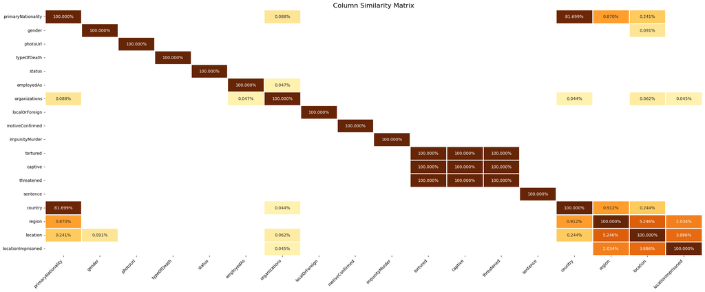

```python
columns = df_clean.select_dtypes(include="object").columns
matrix = pd.DataFrame(index=columns, columns=columns, dtype=float)

for col1 in columns:
    set1 = set(df_clean[col1].dropna().astype(str))

    for col2 in columns:
        set2 = set(df_clean[col2].dropna().astype(str))

        intersection = len(set1 & set2)
        union = len(set1 | set2)

        if union == 0:
            score = 0
        else:
            score = intersection / union

        matrix.loc[col1, col2] = score

plt.figure(figsize=(24,10))

mask = (matrix == 0)

sns.heatmap(
    matrix,
    mask=mask,
    cmap="YlOrBr",
    annot=True,
    fmt=".3%",
    vmax=0.1,
    norm=LogNorm(vmin=0.0001, vmax=1),
    linewidths=1,
    cbar=False
)

plt.title("Column Similarity Matrix", fontsize=16)
plt.xticks(rotation=45, ha="right")
plt.yticks(rotation=0)

plt.tight_layout()
plt.show()
```